# Ex 3_a

Christoffer Mondrup Kramer

2023-05-19

```r
library(tidyverse)
```

# Ex. 3a - Access normality

## QQ-plot

The goal is to access normality of a single variable, here is how it is done.

We start by reading the data frame:

```r
df <- read.table("t4-5.dat", header = FALSE)
df
```

```
##      V1
## 1  0.30
## 2  0.09
## 3  0.30
## 4  0.10
## 5  0.10
## 6  0.12
## 7  0.09
## 8  0.10
## 9  0.09
## 10 0.10
## 11 0.07
## 12 0.05
## 13 0.01
## 14 0.45
```

[output cut: 28 more lines]

We start out by using qqnorm to create the qqplot, and then we put up the qqline, to see how much the observed data differ from a theoretical normal distribution:

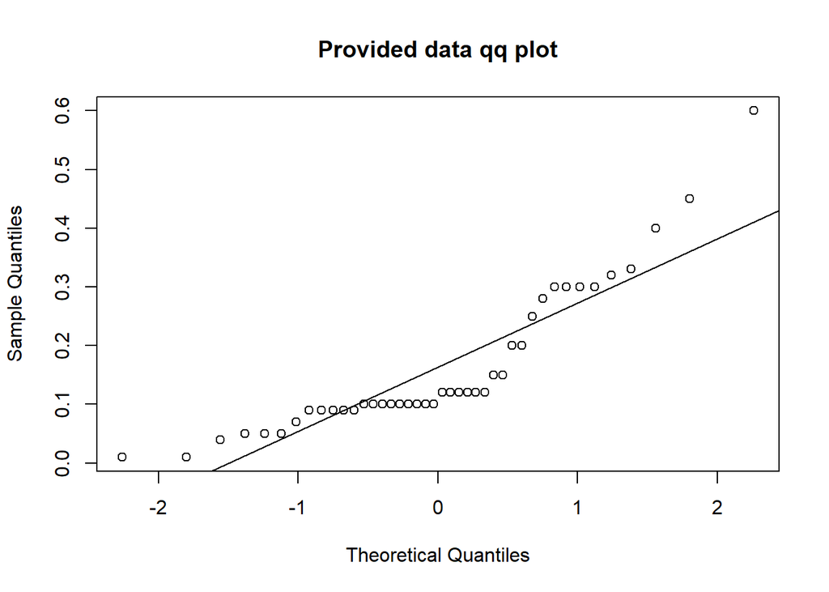

```r
qqc <-qqnorm(df$V1, main = "Provided data qq plot")
qqline(df$V1)
```

We then read the correlation between the theoretical points and the observed points. The closer this is to 1 the better.

```r
cor(qqc$x, qqc$y)
```

```
## [1] 0.9090253
```

0.9 This might seem good, but let’s compare it to a simulation:

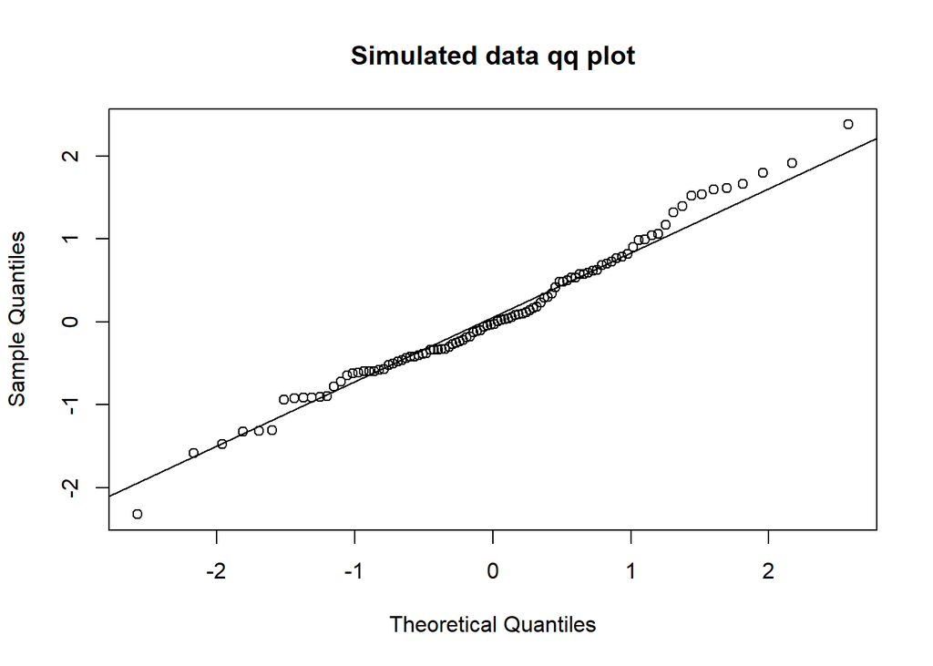

```r
    simu <- rnorm(100)
    qqs <- qqnorm(simu, main = "Simulated data qq plot")
    qqline(simu)
```

This align much better, which is reflected in the correlation:

```r
cors <- cor(qqs$x, qqs$y)
cors
```

```
## [1] 0.9920936
```

It is 0.99 which is much stronger correlation

## Hypothesis test

We have two hypothesis:

H0: Data IS normally distributed H1: Data is NOT normally distributed

For Hypothesis testing we will define a function, which will compare the correlation to the one at p. 181.

```r
reject_hypothesis <- function(data_vector){
  # Create table from book
  n <- c(5, 10, 15, 20, 25, 30, 35, 40, 45, 50, 55, 60, 75, 100, 150, 200, 300)
  one <- c(0.8299, 0.8801, 0.9126, 0.9269, 0.9410,
        0.9479, 0.9538, 0.9599, 0.9632, 0.9671,
        0.9695, 0.9720, 0.9771, 0.9822, 0.9879, 0.9905, 0.9935)

  five <- c(0.8788, 0.9198, 0.9389,
        0.9508, 0.9591, 0.9652,
        0.9682, 0.9726, 0.9749,
        0.9768, 0.9787, 0.9801,
        0.9838, 0.9873, 0.9913, 0.9931, 0.9953)

  ten <- c(0.9032, 0.9351, 0.9503,
        0.9604, 0.9665, 0.9715,
        0.9740, 0.9771, 0.9792,
        0.9809, 0.9822, 0.9836,
        0.9866, 0.9895, 0.9928, 0.9942, 0.9960)
  testing_tbl <- data.frame(
  n,
  one,
  five,
  ten
  )

  # Find out where to look in the table
  exact_sample_size <- FALSE # If the sample size fits perfectly with N in the table this will be true
  sample_size <- length(data_vector)
  i <- 1
  prev_value = NaN
  for (n in testing_tbl$n){

    if (sample_size > testing_tbl$n[length(testing_tbl$n)]){
      i <- length(testing_tbl$n)
      break
    }

    if (n == sample_size){
      exact_sample_size <- TRUE
      break
    }

    else if ( n > sample_size & prev_value < sample_size){
      break
    }
    i <- i + 1
    prev_value <- n
  }

  # Return the intervals we need to look at:
  if (exact_sample_size) {
  print(testing_tbl[i, ])
  }
  else {
    print(testing_tbl[(i - 1) : i, ])
  }

}
```

We then look at the values we are interested in with our n.

```r
reject_hypothesis(df$V1)
```

```
##    n    one   five    ten
## 8 40 0.9599 0.9726 0.9771
## 9 45 0.9632 0.9749 0.9792
```

As we can see our correlation is lower than any, so we have to reject the null hypothesis. THe current data set is NOT normally distributed.

## Transforming data with box cox

Since the data is not normally distributed, we can use a data transformation to make i normal distributed. This is NOT a manipulation, but a transformation.

We first need to find the optimal value

```r
library(MASS)
```

```r
# Make box cox plot on our data
df_box_cox<- boxcox(df$V1~1,lambda=seq(0, 0.5, 2/10))
```

[output not shown]

```r
# Get best lambda
max_lambda <- df_box_cox$x[which.max(df_box_cox$y)]
max_lambda # 0.2626263
```

```
## [1] 0.2626263
```

Now we just need to transform the data:

```r
box_cox_transformation <- function(data_vector, lambda){
  if (lambda == 0){
    transformed_vector <- log(data_vector)
  }

  else {
  transformed_vector <- ((data_vector^lambda) - 1)/lambda
  }

  return(transformed_vector)
}

z_df <- box_cox_transformation(df$V1, max_lambda)
print(z_df)
```

```
##  [1] -1.0321992 -1.7845871 -1.0321992 -1.7278252 -1.7278252 -1.6258133
##  [7] -1.7845871 -1.7278252 -1.7845871 -1.7278252 -1.9138044 -2.0739793
## [13] -2.6716112 -0.7203389 -1.6258133 -1.3125578 -2.1726609 -1.7278252
## [19] -2.6716112 -0.4780427 -1.6258133 -1.7278252 -2.0739793 -2.0739793
## [25] -1.4941269 -1.0321992 -1.4941269 -1.7845871 -1.7845871 -1.0820364
## [31] -1.7278252 -1.7278252 -1.7278252 -1.0321992 -1.6258133 -1.1619650
## [37] -1.3125578 -0.8143778 -0.9618491 -0.9847550 -1.6258133 -1.6258133
```

We can then perform QQ plot:

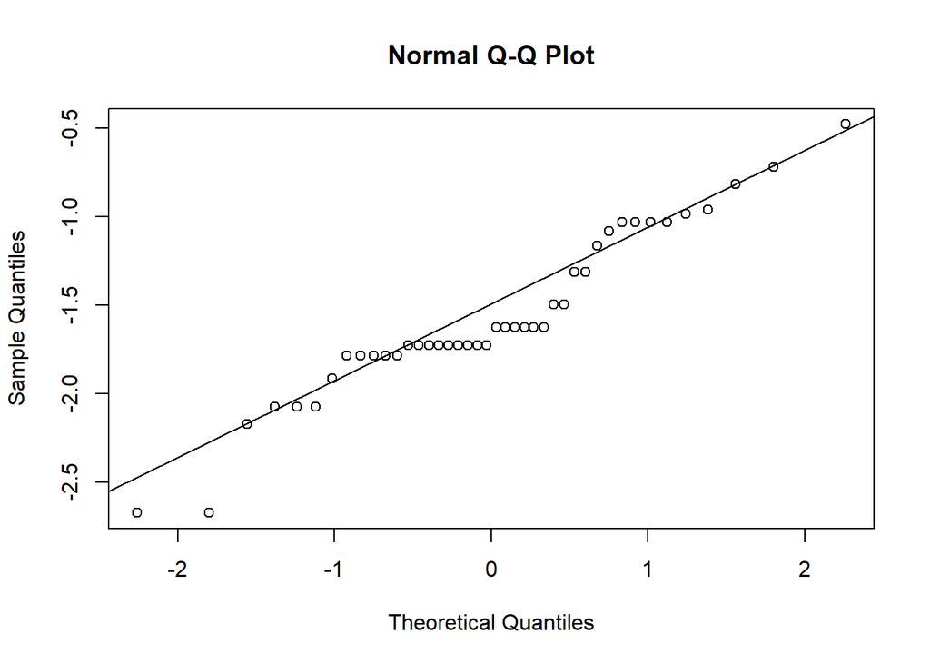

```r
qqz <- qqnorm(z_df)
qqline(z_df)
```

They seem closer but we need to know if they pass the hypothesis test:

```r
reject_hypothesis(z_df)
```

```
##    n    one   five    ten
## 8 40 0.9599 0.9726 0.9771
## 9 45 0.9632 0.9749 0.9792
```

```r
cor(qqz$x, qqz$y)
```

```
## [1] 0.9704366
```

## Full pipeline

```r
box_cox_transformation <- function(data_vector, lambda){
  # Helper function
  if (lambda == 0){
    transformed_vector <- log(data_vector)
  }

  else {
  transformed_vector <- ((data_vector^lambda) - 1)/lambda
  }

  return(transformed_vector)
}


test_norm <- function(data_vector, signigicance = 0.05) {
  # You can chose the following significance levels
  # 0.01
  # 0.05
  # 0.10

  if (signigicance == 0.01){
    signigicance_col <- 2
  }

  else if (signigicance == 0.05){
    signigicance_col <- 3
  }

  else if (signigicance == 0.1){
    signigicance_col <- 4
  }


  # ----- QQ plot -----
  qq <- qqnorm(data_vector, main = "Original Data QQ plot")
  qqline(data_vector)

  print(paste("Length of data is ", length(data_vector)))
  # ----- Hypothesis test ------
  # Create Testing table
  n <- c(5, 10, 15, 20, 25, 30, 35, 40, 45, 50, 55, 60, 75, 100, 150, 200, 300)
  one <- c(0.8299, 0.8801, 0.9126, 0.9269, 0.9410,
        0.9479, 0.9538, 0.9599, 0.9632, 0.9671,
        0.9695, 0.9720, 0.9771, 0.9822, 0.9879, 0.9905, 0.9935)

  five <- c(0.8788, 0.9198, 0.9389,
        0.9508, 0.9591, 0.9652,
        0.9682, 0.9726, 0.9749,
        0.9768, 0.9787, 0.9801,
        0.9838, 0.9873, 0.9913, 0.9931, 0.9953)

  ten <- c(0.9032, 0.9351, 0.9503,
        0.9604, 0.9665, 0.9715,
        0.9740, 0.9771, 0.9792,
        0.9809, 0.9822, 0.9836,
        0.9866, 0.9895, 0.9928, 0.9942, 0.9960)
  testing_tbl <- data.frame(
  n,
  one,
  five,
  ten
  )

  # Find index of testing (n)
  sample_size <- length(data_vector)
  i <- 1
  prev_value = NaN
  for (n in testing_tbl$n){

    if (sample_size > testing_tbl$n[length(testing_tbl$n)]){
      i <- length(testing_tbl$n)
      break
    }

    if (n == sample_size){
      exact_sample_size <- TRUE
      break
    }

    else if ( n > sample_size & prev_value < sample_size){
      break
    }
    i <- i + 1
    prev_value <- n
  }

  print(testing_tbl[(i - 1) : i, ])
  # ----- Normal -------
  cor_coef <- cor(qq$x, qq$y)
  normality = FALSE
  if (cor_coef > testing_tbl[i, signigicance_col]){
    print(paste("With a correlation coefficient of ", cor_coef, "The data is normal within significance levels of", signigicance))
    normality = TRUE
    return(normality)
  }


  # ----- Not normal -----
  else {


    print(paste("With a correlation coefficient of ", cor_coef,
                "The data is not normal within significance levels of", signigicance, "Transforming data ... "))

    # Transform data
    # Make box cox plot on our data
    df_box_cox<- boxcox(df$V1~1,lambda=seq(0, 0.5, 2/10))
    df_box_cox

    # Get best lambda
    max_lambda <- df_box_cox$x[which.max(df_box_cox$y)]
    print(paste("The best lambda is ", max_lambda))

    # Transform data
    z_vector <- box_cox_transformation(data_vector, max_lambda)

    # QQ plot on transformed data
    qqz <- qqnorm(z_vector, main = "Transformed Data QQ plot")
    qqline(z_vector)

    # Hypothesis test on transformed data
    z_cor_coef <- cor(qqz$x, qqz$y)
    if (z_cor_coef > testing_tbl[i, signigicance_col]){
      print(paste("With a correlation coefficient of ", z_cor_coef,
                  "The data is normal within significance levels of", signigicance,
                  "For the box cox transformed data"))
      normality = TRUE
      return(normality)
    }

    else {
        print(paste("With a correlation coefficient of ", z_cor_coef,
              "The data is normal within significance levels of", signigicance,
              "For the box cox transformed data"))
    }


  }




}
```

```r
test_norm(df$V1, signigicance = 0.01)
```

```
## [1] "Length of data is  42"
##    n    one   five    ten
## 8 40 0.9599 0.9726 0.9771
## 9 45 0.9632 0.9749 0.9792
## [1] "With a correlation coefficient of  0.909025275553708 The data is not normal within significance levels of 0.01 Transforming data ... "
```

```
## [1] "The best lambda is  0.262626262626263"
```

```
## [1] "With a correlation coefficient of  0.970436639721784 The data is normal within significance levels of 0.01 For the box cox transformed data"
```

```
## [1] TRUE
```

```r
test_norm(df$V1, signigicance = 0.05)
```

```
## [1] "Length of data is  42"
##    n    one   five    ten
## 8 40 0.9599 0.9726 0.9771
## 9 45 0.9632 0.9749 0.9792
## [1] "With a correlation coefficient of  0.909025275553708 The data is not normal within significance levels of 0.05 Transforming data ... "
```

```
## [1] "The best lambda is  0.262626262626263"
```

```
## [1] "With a correlation coefficient of  0.970436639721784 The data is normal within significance levels of 0.05 For the box cox transformed data"
```

```r
test_norm(df$V1, signigicance = 0.10)
```

```
## [1] "Length of data is  42"
##    n    one   five    ten
## 8 40 0.9599 0.9726 0.9771
## 9 45 0.9632 0.9749 0.9792
## [1] "With a correlation coefficient of  0.909025275553708 The data is not normal within significance levels of 0.1 Transforming data ... "
```

```
## [1] "The best lambda is  0.262626262626263"
```

```
## [1] "With a correlation coefficient of  0.970436639721784 The data is normal within significance levels of 0.1 For the box cox transformed data"
```

## Other

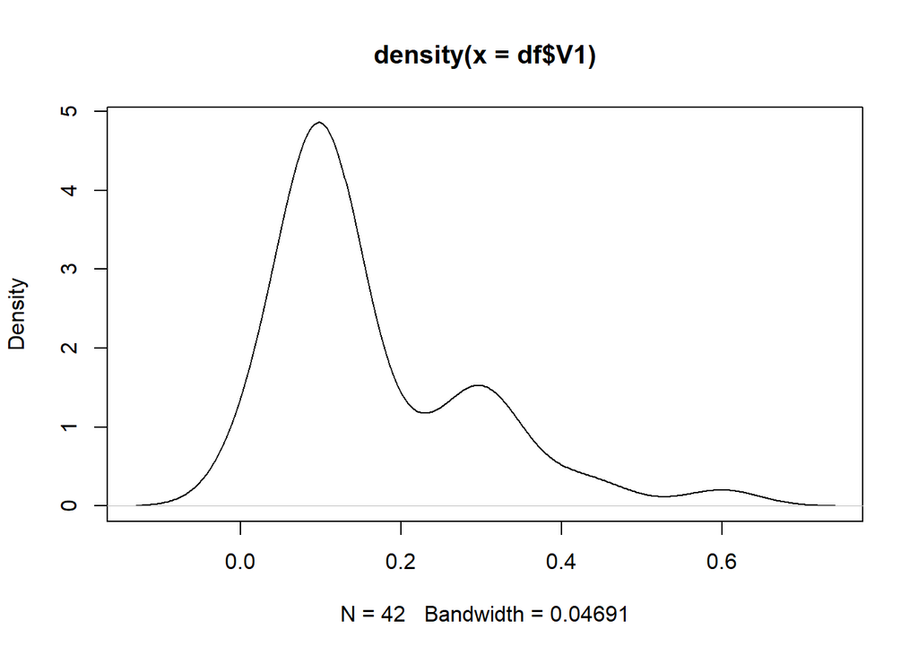

```r
# Our data
d <- density(df$V1) # PDC
plot(d)
```

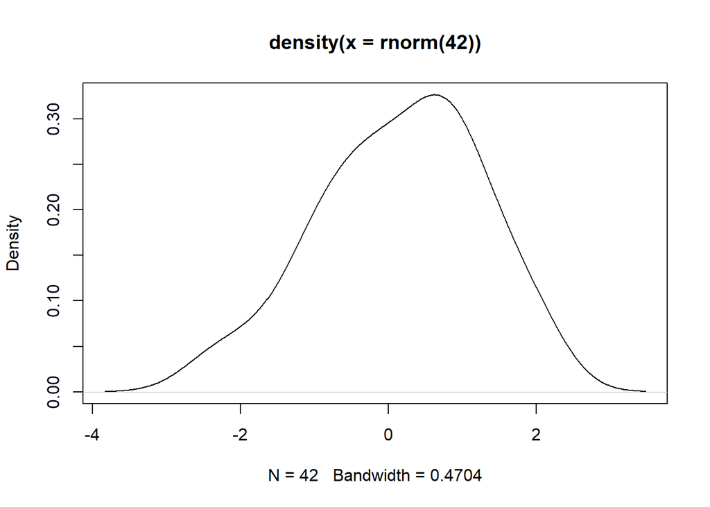

```r
# Simulated
simu <- density(rnorm(42))
plot(simu)
```

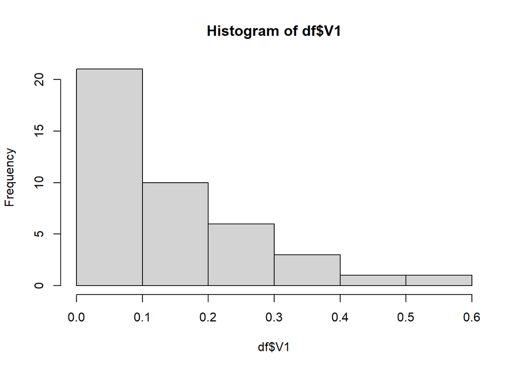

```r
hist(df$V1)
```

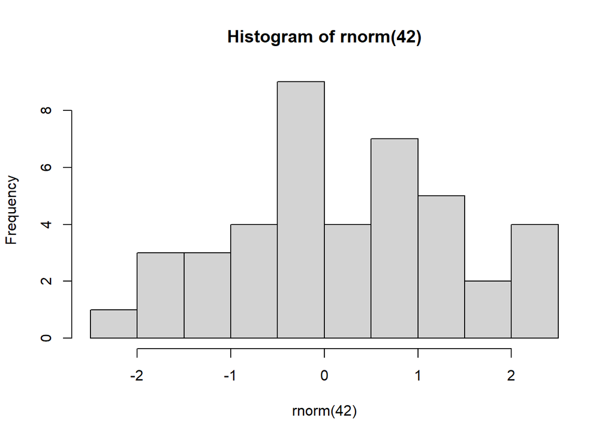

```r
hist(rnorm(42))
```

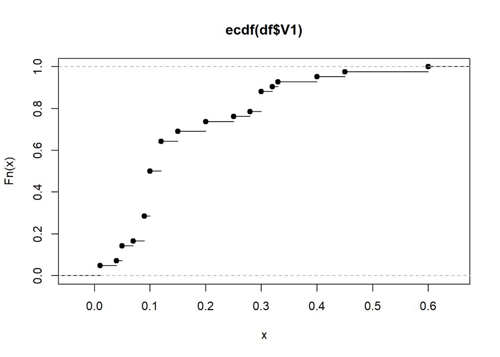

```r
cdf <- ecdf(df$V1) # Cumulative density function
plot( cdf )
```

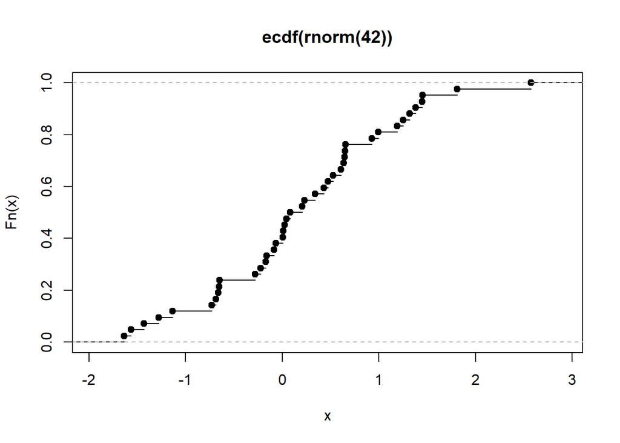

```r
simu_cdf <- ecdf(rnorm(42))
plot(simu_cdf)
```